# Introduction to R for Life Scientists

### Slicing/indexing vectors

Let's create a vector of 50 integers going from 101 to 150. We can access certain elements of that vector by putting the element's *index(es)* in square brackets. E.g., `x[1]` will return the first element in vector `x`. Calling `x[c(3,5)]` will access the third and fifth elements. Calling `x[1:10]` will return the first ten elements of `x`.

*Special note: R indexes vectors starting at 1. This is different from many other languages, including Perl and Python, which index starting from zero.*

```r
# Create the vector.
x <- 101:150

# Get the first element.
x[1]

# Get the 42nd element.
x[42]

# Get the 20th through the 25th elements.
x[20:25]

# If you try to access elements that don't exist, you'll return missing
# values.  Missing values are represented as NA
x[45:55]  #NA is missing value!
```

### Data Frames

Data frames are a standard way to store heterogeneous tabular data in R: tabular, meaning that individuals or observations are typically represented in rows, while variables or features are represented as columns; heterogeneous, meaning that columns/features/variables can be different classes (on variable, e.g. age, can be numeric, while another, e.g., cause of death, can be text).

Later on we'll go over how we load our own data, but for now, let's use a built-in data frame called `mtcars`. This data was extracted from the 1974 Motor Trend US magazine, and comprises fuel consumption and 10 aspects of automobile design and performance for 32 automobiles (1973–74 models). We can load this built-in data with `data(mtcars)`. By the way, running `data()` without any arguments will list all the available built-in datasets included with R.

Let's load the data first. Type the name of the object itself (`mtcars`) to view the entire data frame. *Note: doing this with large data frames can cause you trouble.*

```r
data(mtcars)
class(mtcars)
mtcars
```

There are several built-in functions that are useful for working with data frames.

- `head()` prints the first few lines of a large data frame.
- `length()` tells you the number of features (variables, columns) in a data frame.
- `dim()` returns a two-element vector containing the number of rows and the number of columns in a data frame.
- `str()` displays the structure of a data frame, printing out details and a preview of every column.
- `summary()` works differently depending on what kind of object you pass to it. Passing a data frame to the `summary()` function prints out some summary statistics about each column (min, max, median, mean, etc.)

```r
head(mtcars)
length(mtcars)
dim(mtcars)
dim(mtcars)[1]  # number of rows (individual cars in the survey)
dim(mtcars)[2]  # number of columns (number of variables measured)
str(mtcars)
```

We can access individual variables within a data frame using the `$` operator, e.g., `mydataframe$specificVariable`. Let's print out the number of cylinders for every car, and calculate the average miles per gallon for ever car in the dataset (using the built-in `mean()` function).

```r
# display the number of cylinders for each car.
mtcars$cyl
# first display MPG for all vehicles, then calculate the average.
mtcars$mpg
mean(mtcars$mpg)
```

We can also access certain rows or columns of a dataset by providing multiple indices using the syntax `mydataframe[rows, columns]`. Let's get the first 4 rows and the first two rows (MPG and # cylinders) from the dataset:

```r
head(mtcars)
mtcars[1:4, 1:2]
```

We can also use the `subset()` function to return a subset of the data frame that meets a specific condition. The first argument is the data frame you want to subset. The second argument is a condition you must satisfy. If you want to satisfy *all* of multiple conditions, you can use the “and” operator, `&`. The “or” operator `|` (the pipe character, usually shift-backslash) will return a subset that meet *any* of the conditions.

The commands below will:

Try some subsetting on your own.

```r
subset(mtcars, cyl == 6)
subset(mtcars, cyl > 6)
subset(mtcars, mpg >= 20 | disp < 100)
subset(mtcars, cyl == 6, select = c(mpg, disp))
subset(mtcars, cyl >= 6 & mpg >= 15, select = c(mpg, cyl, qsec))
```

The `with()` function is particularly helpful. Let's say you wanted to compute some (senseless) value by computing the MPG times the number of cylinders divided by the car's displacement. You could access the dataset's variables using the `$` notation, or you could use `with()` to temporarily *attach* the data frame, and call the variables directly. The first argument to `with()` is the name of the data frame, and the second argument is all the stuff you'd like to do with the particular features in that data frame.

Try typing the following commands:

```r
# Display the number of cylinders.
mtcars$cyl
with(mtcars, cyl)

# Compute the senseless value described above. Both return the same results.
mtcars$mpg * mtcars$cyl/mtcars$disp
with(mtcars, mpg * cyl/disp)
```

### Plotting

Plotting a single numeric variable goes down the rows and plots a value on the y-axis for each observation (index) in the data frame.

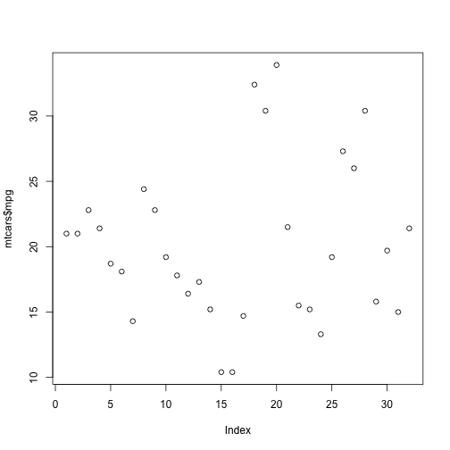

```r
plot(mtcars$mpg)
```

This isn't a very useful figure. More appropriate might be a histogram. We can try to let R decide how many breaks to insert in the histogram, or we can set that manually. We can also set the color of the bars.

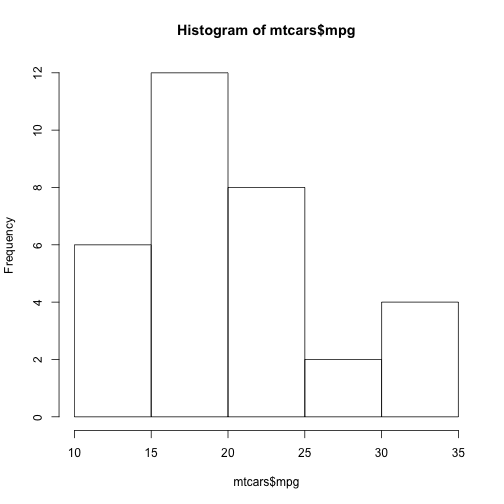

```r
hist(mtcars$mpg)
```

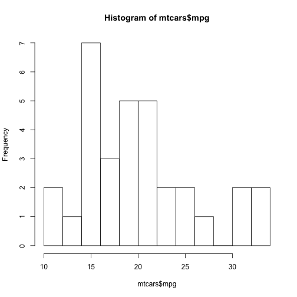

```r
hist(mtcars$mpg, breaks = 10)
```

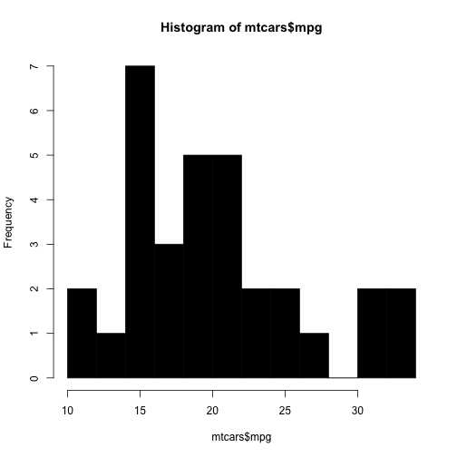

```r
hist(mtcars$mpg, breaks = 10, col = "black")
```

We can create a scatterplot between two variables with `plot(varX, varY)`.

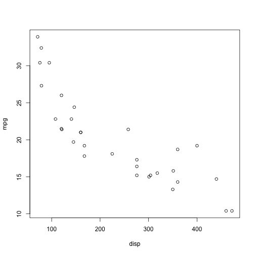

```r
# This would also work, but let's use with().  plot(mtcars$disp, mtcars$mpg)
with(mtcars, plot(disp, mpg))
```

There are hundreds of plotting parameters you can use to make your plot look exactly like you want. Let's use a solid-filled point instead of an open circle with the `pch=` argument, color the points red with the `col=` argument, give it a title by passing a character object to the `main=` argument, and change the x and y axis titles with the `xlab=` and `ylab=` arguments, respectively. Let's go through this one step at a time.

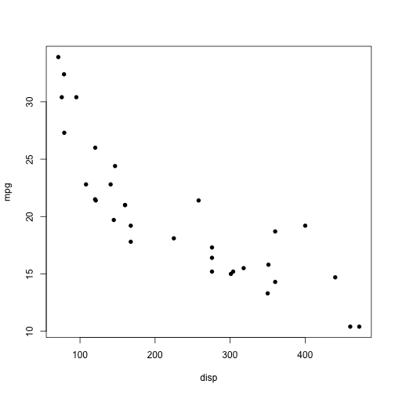

```r
with(mtcars, plot(disp, mpg, pch = 16))
```

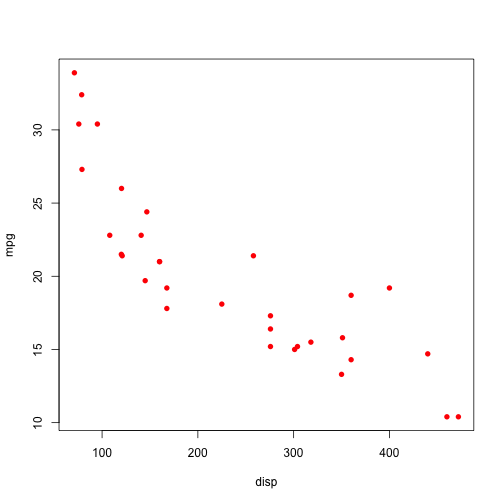

```r
with(mtcars, plot(disp, mpg, pch = 16, col = "red"))
```

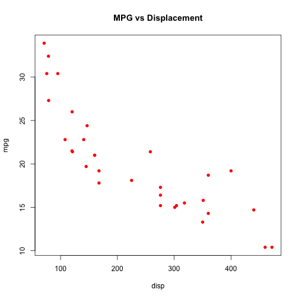

```r
with(mtcars, plot(disp, mpg, pch = 16, col = "red", main = "MPG vs Displacement"))
```

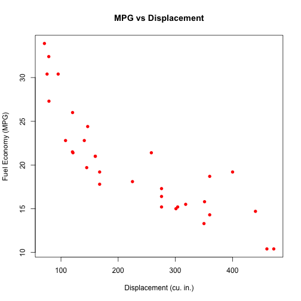

```r
with(mtcars, plot(disp, mpg, pch = 16, col = "red", main = "MPG vs Displacement",
    ylab = "Fuel Economy (MPG)", xlab = "Displacement (cu. in.)"))
```

Notice how on that last line I broke the command up into two lines for better readability. I broke the command at the comma separating arguments, and indented the following line for readability.

On your own, try plotting horsepower vs displacement for vehicles with more than 4 cylinders. Give the graph a title and label the axes. Make the points solid (hint, `pch=16`) blue (hint, `col="blue"`) circles. Your plot should look something like this:

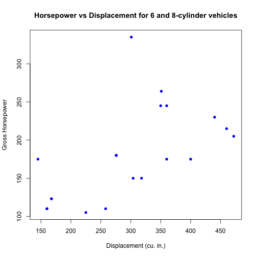

### Reading in / writing out data

First, lets create a small dataset consisting of only 8 cylinder cars.

```r
mtcars_8cyl <- subset(mtcars, cyl == 8)
mtcars_8cyl
```

Next, check what your working directory is with `getwd()` with no arguments, and look up some help for `write.table()` and `write.csv()`.

```r
getwd()
help(write.table)
help(write.csv)
```

Using RStudio, go to the Session menu, and select the directory (folder) you want to work from under the “Set Working Directory” menu. You can also do this manually with the `setwd()` command.

```r
getwd()
setwd("/Users/sdt5z/Desktop/R")
```

Once you've set your working directory either using RStudio or on the command line, save the new reduced data frame to a comma-separated file called `cars8.csv` using the `write.csv()` function.

```r
write.csv(mtcars_8cyl, file = "cars8.csv")
```

Data can be loaded using the Tools – Import Dataset – From text file menu in R studio. Or you can also load a dataset manually using `read.table()` or `read.csv()`. First, read the help on these functions:

```r
help(read.table)
help(read.csv)
```

Here let's remove the dataset, and re-import it into an object called cars8 from the file we just saved.

```r
rm(mtcars_8cyl)
mtcars_8cyl
cars8 <- read.table(file = "cars8.csv", header = TRUE, sep = ",", row.names = 1)
cars8
rm(cars8)
cars8 <- read.csv(file = "cars8.csv", header = TRUE, row.names = 1)
cars8
```

## Using R and Bioconductor for gene expression analysis

In this section we'll analyze some publicly available gene expression data using R and bioinformatics-focused R packages in [Bioconductor](http://bioconductor.org/). But first, a bit about R *packages*.

### Packages

Most generic R packages are hosted on the Comprehensive R Archive Network (CRAN, http://cran.us.r-project.org/). To install one of these packages, you would use `install.packages("packagename")`. You only need to install a package once, then load it each time using `library(packagename)`. Let's install the `ggplot2` package, and load it.

```r
# Install only once.
install.packages("ggplot2")

# Load the package every time you want to use it.
library(ggplot2)
```

### Bioconductor

Bioconductor packages work a bit different, and are not hosted on CRAN. Go to http://bioconductor.org/ to learn more about the Bioconductor project. To use any Bioconductor package, you'll need a few “core” Bioconductor packages. Run the following commands to (1) download the installer script, and (2) install some core Bioconductor packages. You'll need internet connectivity to do this, and it'll take a few minutes, but it only needs to be done once.

```r
# Download the installer script
source("http://bioconductor.org/biocLite.R")

# biocLite() is the bioconductor installer function.  Run it without any
# arguments to install the core packages or update any installed packages.
# This requires internet connectivity and will take some time!
biocLite()
```

To install specific packages, first download the installer script if you haven't done so, and use `biocLite("packagename")`. This only needs to be done once then you can load the package like any other package. Let's download the [limma package](http://www.bioconductor.org/packages/release/bioc/html/limma.html):

```r
# Do only once
source("http://bioconductor.org/biocLite.R")
biocLite("limma")

# Every time you need to use the limma package
library(limma)
```

Bioconductor packages usually have great documentation in the form of *vignettes*. For a great example, take a look at the [limma user's guide](http://www.bioconductor.org/packages/release/bioc/vignettes/limma/inst/doc/usersguide.pdf).

### Analyzing publicly available microarray data

Now, let's analyze some publicly available gene expression microarray data. NCBI Gene Expression Omnibus (http://www.ncbi.nlm.nih.gov/geo/) is an international public repository that archives and freely distributes microarray, next-generation sequencing, and other forms of high-throughput functional genomics data submitted by the research community. Many publishers require gene expression data be submitted to GEO and made publicly available before publication. You can learn a lot more about GEO by reading their [overview](http://www.ncbi.nlm.nih.gov/geo/info/overview.html) and [FAQ](http://www.ncbi.nlm.nih.gov/geo/info/faq.html) pages. At the time of this writing, GEO hosts over 45,000 studies comprising over 1,000,000 samples on over 10,000 different technology platforms.

In this demonstration, we're going to be using data from GEO Series accession number GSE25724. You can enter this number in the search box on the GEO homepage, or use [this direct link](http://www.ncbi.nlm.nih.gov/geo/query/acc.cgi?acc=GSE25724). In this study, the authors performed microarray analysis to evaluate differences in the transcriptome of type 2 diabetic human islets compared to non-diabetic islet samples. Human pancreatic islets were isolated from the pancreas of organ donors by collagenase digestion followed by density gradient purification, then hand-picked and cultured two days in M199 culture medium. Seven non-diabetic islet samples and six diabetic islet samples were hybridized to the Affymetrix GeneChip Human Genome U133A microarray. The results were published in: Dominguez V, et al. Class II phosphoinositide 3-kinase regulates exocytosis of insulin granules in pancreatic beta cells. *J Biol Chem 2011* Feb 11;286(6):4216-25. PMID: 21127054.

You can go to the [GEO accession page](http://www.ncbi.nlm.nih.gov/geo/query/acc.cgi?acc=GSE25724) and download the raw .CEL file data directly (at the very bottom, under “Supplementary file”). However, we are going to use a Bioconductor package called [GEOquery](http://www.bioconductor.org/packages/release/bioc/html/GEOquery.html) that allows us to *programmatically* access all data in GEO from within R. Take a look at the [GEOquery vignette](http://www.bioconductor.org/packages/release/bioc/vignettes/GEOquery/inst/doc/GEOquery.pdf) or Google around for “GEOquery tutorial” to learn more.

#### Load packages

First, we'll need to load the Bioconductor packages we'll be using:

```r
# Bioconductor packages.  Use the installation instructions at
# http://www.bioconductor.org/install/ if you haven't already installed
# these (install once, load every time)
library(Biobase)
library(GEOquery)
library(limma)
library(arrayQualityMetrics)
```

#### Acquire and pre-process the data

Next, let's get the data and verify that it's an [ExpressionSet](http://bioconductor.org/packages/release/bioc/vignettes/Biobase/inst/doc/ExpressionSetIntroduction.pdf)-class object.

```r
gset <- getGEO("GSE25724", GSEMatrix = TRUE, destdir = ".", AnnotGPL = TRUE)
gset <- gset[[1]]
class(gset)
```

Next we'll fix the names of the variables describing the features (probes) on the array. The variable names are non-standard, having things like spaces (e.g. `"Gene title"`) and colons (e.g. `"GO:Function"`), which can cause problems downstream. The `make.names()` function makes syntactically valid names out of character vectors.

```r
# Removes spaces, colons, other weird symbols, inserts '.' instead.
fvarLabels(gset) <- make.names(fvarLabels(gset))
```

Next, let's take a look at the sample metadata. We can see that the first seven samples are non-diabetic islets and the last six are diabetic. Let's create a `condition` variable that indicates the disease state of each sample, and annotate the dataset's description with this new condition variable.

```r
# group names for all samples
View(pData(gset))
rep("ctrl", 7)
rep("diab", 6)
condition <- c(rep("ctrl", 7), rep("diab", 6))
condition <- as.factor(condition)
gset$description <- condition
```

#### Quality assessment

Before we do any analysis, let's do some quality assessment using the [arrayQualityMetrics](http://www.bioconductor.org/packages/release/bioc/html/arrayQualityMetrics.html) Bioconductor package. Note that this can take a few minutes and a good deal of RAM for multiple samples. The `arrayQualityMetrics()` function produces a number of useful outputs in a tidy HTML report. Open up the index.html file produced in the output directory and look at the metadata overview, between-array comparisons (distance heatmap/dendrograms, PCA), array density distrubutions (boxplots and density plots), variance-mean dependence, and MA plots. The text below each figure in the QA report gives a description of each figure and what you should be seeing.

```r
arrayQualityMetrics(gset, outdir = "aqm-report", intgroup = "description")
```

#### Differential expression analysis

Finally, we'll do some data analysis. Below I'm using the [limma](http://www.bioconductor.org/packages/release/bioc/html/limma.html) (linear models for microarray) Bioconductor package for the analysis. Here we have a very simple two-group comparison, but limma can handle very complex multi-factorial designs including time-series, paired samples, and nested interaction models, among others.

First we specify a *design matrix* which indicates the experimental condition of each sample. Then we specify a *contrast* matrix that indicates the exact comparisons we want to do between samples. For an experiment that's this simple we don't really need a contrast matrix since the contrast that we want to perform (diabetic vs non-diabetic) is implicit in the design, but we di it here anyway for clarity.

```r
# Set up and view the design matrix
design <- model.matrix(~description + 0, data = gset)
colnames(design) <- levels(condition)
design

# Set up and view the contrast matrix
cont.matrix <- makeContrasts(diab - ctrl, levels = design)
cont.matrix

# Fit a linear model, compute contrast coefficients and std errs, moderated
# t-tests and p-values:
fit <- lmFit(gset, design)
fit <- contrasts.fit(fit, cont.matrix)
fit <- eBayes(fit, proportion = 0.01)

# Extract the top 250 most differentially expressed genes, with an FDR
# correction
tt <- topTable(fit, adjust = "fdr", sort.by = "p", number = 250)

# Look at the results in RStudio
View(tt)

# Export the results to file
write.table(tt, file = "top-250-genes.csv", row.names = F, sep = ",")
```

#### Record package and version info with `sessionInfo()`

The `sessionInfo()` prints version information about R and any attached packages. It's a good practice to always run this command at the end of your R session and record it for the sake of reproducibility in the future.

[session information not shown]